# ggplot2: 2 First Steps

## 2.6.6 Plot Geoms

1.What’s the problem with the plot created by ggplot(mpg, aes(cty, hwy)) + geom_point()? Which of the geoms described above is most effective at remedying the problem?

The problem is the scatterplot has noise obscuring the data. Adding geom_smooth highlights the trend shown by the points.

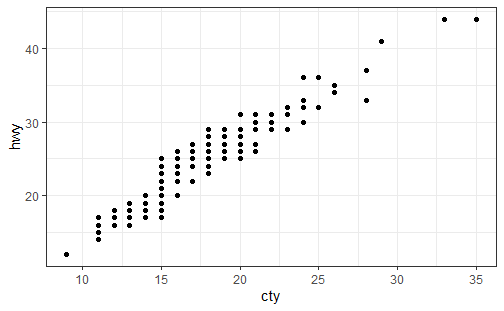

```r
# given
ggplot(mpg, aes(cty, hwy)) +
  geom_point()
```

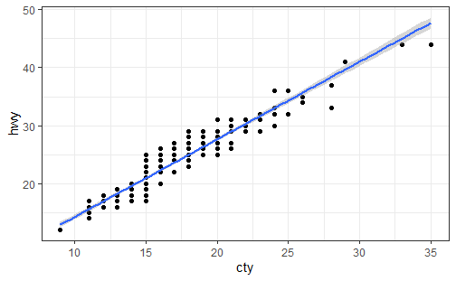

```r
# add smoother to see trend
ggplot(mpg, aes(cty, hwy)) +
  geom_point() +
  geom_smooth(method = "lm", formula = "y ~ x")
```

2a.One challenge with ggplot(mpg, aes(class, hwy)) + geom_boxplot() is that the ordering of class is alphabetical, which is not terribly useful. How could you change the factor levels to be more informative?

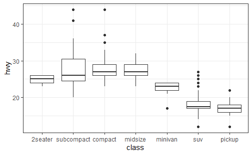

2b.Rather than reordering the factor by hand, you can do it automatically based on the data: ggplot(mpg, aes(reorder(class, hwy), hwy)) + geom_boxplot(). What does reorder() do? Read the documentation.

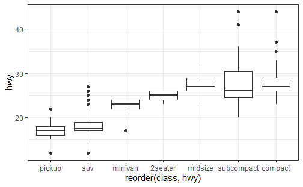

3.Explore the distribution of the carat variable in the diamonds dataset. What binwidth reveals the most interesting patterns?

A better binwidth shows the marketing pattern of that whole numbers and even divisions are preferred.

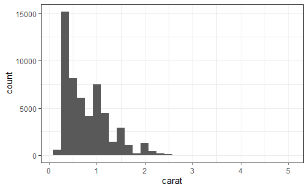

```r
# default bins
ggplot(diamonds, aes(carat)) +
         geom_histogram()
```

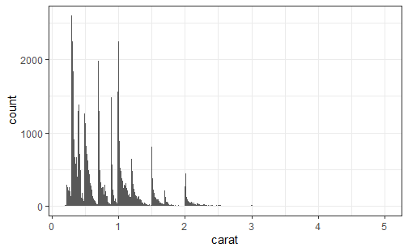

```r
# better to see the pattern
ggplot(diamonds, aes(carat)) +
         geom_histogram(binwidth = 0.01)
```

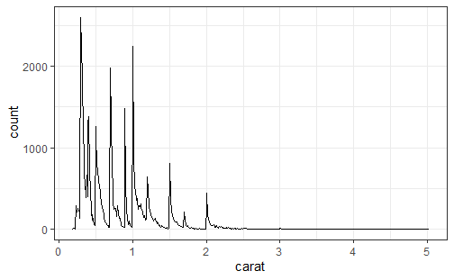

```r
# another the pattern
ggplot(diamonds, aes(carat)) +
         geom_freqpoly(binwidth = 0.01)
```

[output not shown]

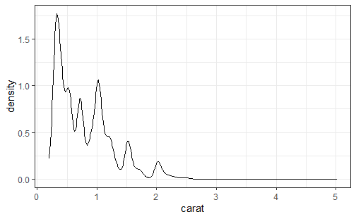

```r
ggplot(diamonds, aes(carat)) +
         geom_density(binwidth = 0.01)
```

4.Explore the distribution of the price variable in the diamonds data. How does the distribution vary by cut?

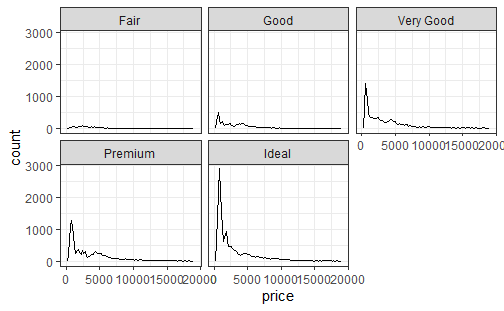

```r
# compare price distribution in cuts
ggplot(diamonds, aes(price)) +
  geom_freqpoly(binwidth = 200) +
  facet_wrap(~cut)
```

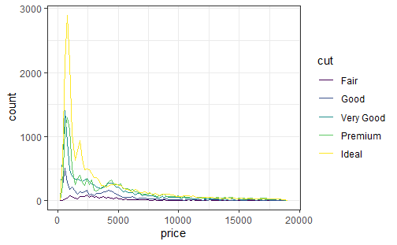

```r
# compare to info in one graph
ggplot(diamonds, aes(price, colour = cut)) +
  geom_freqpoly(binwidth = 200)
```

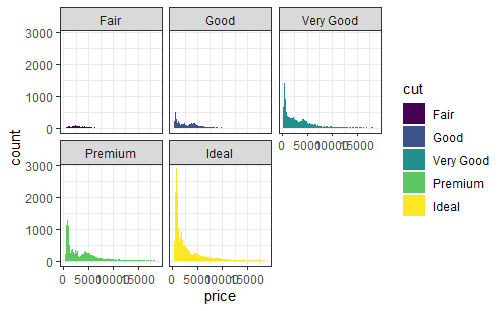

```r
# another way
ggplot(diamonds, aes(price, fill = cut)) +
  geom_histogram(binwidth = 200) +
  facet_wrap(~cut)
```

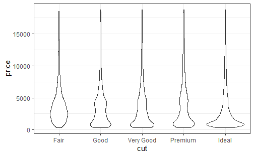

```r
# with violin graph
ggplot(diamonds, aes(cut, price)) +
  geom_violin()
```

5.You now know (at least) three ways to compare the distributions of subgroups: geom_violin(), geom_freqpoly() and the colour aesthetic, or geom_histogram() and faceting. What are the strengths and weaknesses of each approach? What other approaches could you try?

geom_violin - show a compact representation of the “density” of the distribution, highlighting the areas where more points are found. Weakness is that these graphs are harder to interpret.

geom_freqpoly() and the colour aesthetic - easier to compare but distribution may overlap.

geom_histogram() and faceting - easier to see individual distributions but harder to compare directly.

other approaches: geom_boxplot…

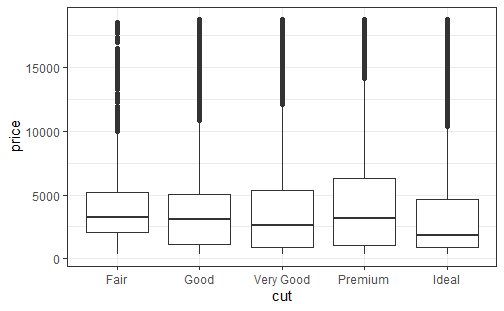

7.Read the documentation for geom_bar(). What does the weight aesthetic do?

geom_bar() makes the height of the bar proportional to the number of cases in each group (or if the weight aesthetic is supplied, the sum of the weights)

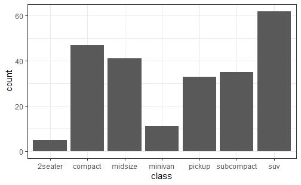

```r
#?geom_bar

ggplot(mpg, aes(class)) +
  geom_bar(aes())
```

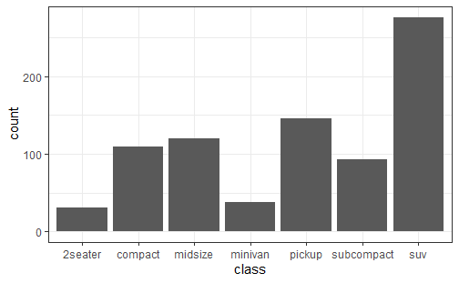

```r
ggplot(mpg, aes(class)) +
  geom_bar(aes(weight = displ))
```

7.Using the techniques already discussed in this chapter, come up with three ways to visualise a 2d categorical distribution. Try them out by visualising the distribution of model and manufacturer, trans and class, and cyl and trans.

Stacked bar charts using geom_bar(position = “stack”)

Grouped bar chart using geom_bar(position = “dodge”)

Segmented bar chart using geom_bar(position = “fill”)

(or sta_bin_2d; Bubble graphs from ggpubr)

[figure not shown]

```r
ggplot(mpg,
       aes(x = manufacturer,
           fill = model)) +
  geom_bar(position = "fill") +
  labs(y = "Proportion") +
  coord_flip() +
  theme(legend.position = "bottom")
```

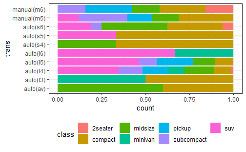

```r
ggplot(mpg, aes(trans, fill = class)) +
  geom_bar(position = "fill") +
  theme(legend.position = "bottom") +
  coord_flip()
```

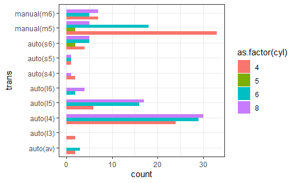

```r
ggplot(mpg, aes(trans, fill = as.factor(cyl))) +
  geom_bar(position = position_dodge(preserve = "single")) +
  coord_flip()
```

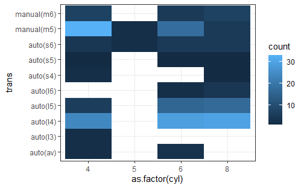

```r
ggplot(mpg, aes(trans, as.factor(cyl))) +
  stat_bin_2d() +
  coord_flip()
```

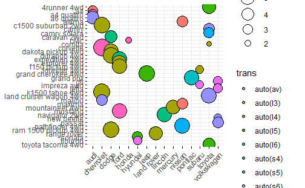

```r
# something totally different for categorical data
  ggpubr::ggballoonplot(mpg, fill = "trans")
```

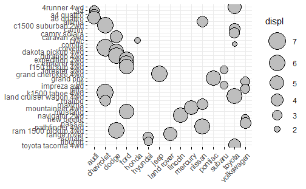

```r
# takes first three
  ggpubr::ggballoonplot(mpg)
```

## 2.7 Modifying the axes

No exercises

## 2.8 Output

No exercises